[figure not shown]

# Métodos Computacionais II

2018/2

[Jony Arrais Pinto Junior](http://lattes.cnpq.br/4940428746026448)

## 1 - Conteúdo Aula 11

- Teste de hipóteses usando o R

## 2 - Teste de hipóteses para a média de uma população normal com variância desconhecida

Considere uma amostra aleatória simples $X_1, \ldots, X_n$ obtida de uma população normal com média $\mu$ e variância $\sigma^2$ desconhecida.

Suponha que deseja-se testar a seguinte hipótese sobre $\mu$,
$$H_0: \mu = 500 \qquad \times \qquad H_1: \mu > 500.$$

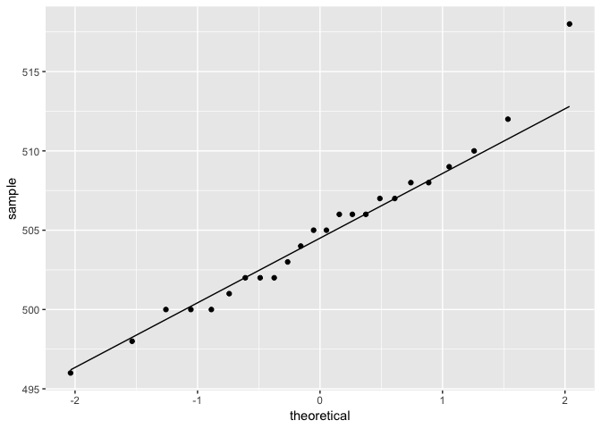

```r
library(ggplot2)

amostra = c(507, 510, 503, 505, 506, 505, 506, 500, 506, 518, 512, 502, 508, 508, 500, 502, 509, 500, 504, 496, 498, 507, 502, 501)

ggplot(data = data.frame(variavel = amostra), aes(sample = variavel)) + stat_qq() + stat_qq_line()
```

```r
#Conclusão?!

t.test(amostra, alternative = "greater", mu = 500)
```

```
##
##  One Sample t-test
##
## data:  amostra
## t = 4.8448, df = 23, p-value = 3.428e-05
## alternative hypothesis: true mean is greater than 500
## 95 percent confidence interval:
##  503.0966      Inf
## sample estimates:
## mean of x
##  504.7917
```

### Qual a sua conclusão?

Suponha que deseja-se testar a seguinte hipótese sobre $\mu$,
$$H_0: \mu = 500 \qquad \times \qquad H_1: \mu \neq 500.$$

```r
t.test(amostra, alternative = "two.sided", mu = 500, conf.level = 0.93)
```

```
##
##  One Sample t-test
##
## data:  amostra
## t = 4.8448, df = 23, p-value = 6.857e-05
## alternative hypothesis: true mean is not equal to 500
## 93 percent confidence interval:
##  502.9122 506.6711
## sample estimates:
## mean of x
##  504.7917
```

## 2 - Teste de hipóteses para a variância de uma população normal

Considere uma amostra aleatória simples $X_1, \ldots, X_n$ obtida de uma população normal com média $\mu$ e variância $\sigma^2$ desconhecida.

Suponha que deseja-se testar a seguinte hipótese sobre $\sigma^2$,
$$H_0: \sigma^2 = 25 \qquad \times \qquad H_1: \sigma^2 \neq 25.$$

```r
library(DescTools)

VarTest(amostra, alternative = "two.sided", sigma.squared = 25, conf.level = 0.95)
```

```
##
##  One Sample Chi-Square test on variance
##
## data:  amostra
## X-squared = 21.598, df = 23, p-value = 0.9108
## alternative hypothesis: true variance is not equal to 25
## 95 percent confidence interval:
##  14.18121 46.19549
## sample estimates:
## variance of x
##      23.47645
```

## 3 - Teste de hipóteses para a proporção

Suponha que deseja-se testar a hipótese de que a proporção de pacotes com peso inferior a 500 é menor do que $25\%$ (Proporção populacional),
$$H_0: p = 0,25 \qquad \times \qquad H_1: p < 0,25.$$

```r
proporcao = ifelse(amostra < 500, 1, 0)

proporcao
```

```
##  [1] 0 0 0 0 0 0 0 0 0 0 0 0 0 0 0 0 0 0 0 1 1 0 0 0
```

```r
prop.test(sum(proporcao), length(proporcao), alternative = "less", p = 0.25, correct = FALSE)
```

```
##
##  1-sample proportions test without continuity correction
##
## data:  sum(proporcao) out of length(proporcao), null probability 0.25
## X-squared = 3.5556, df = 1, p-value = 0.02967
## alternative hypothesis: true p is less than 0.25
## 95 percent confidence interval:
##  0.0000000 0.2231209
## sample estimates:
##          p
## 0.08333333
```

## 4 - Calculo do Erro tipo 2, Poder do Teste e p-valor para o teste de hipóteses da média de uma população normal com variância populacional conhecida

### 4.1 - Erro Tipo II (Teste unilateral a direita)

Considere uma amostra aleatória simples $X_1, \ldots, X_n$ obtida de uma população normal com média $\mu$ e variância $\sigma^2 = 25$ conhecida.

Suponha que deseja-se testar a seguinte hipótese sobre $\mu$,
$$H_0: \mu = 500 \qquad \times \qquad H_1: \mu > 500.$$

O teste acima possui uma região crítica definida por
$$RC = \{\bar{x}: \bar{x} > k\}.$$

Se desejamos calcular o Erro tipo II (chamado de $\beta$) associado ao teste acima, devemos calcular

$\beta$ = P(Erro Tipo II) = P(Não Rejeitar $H_0$ | $H_0$ é falso) = P($\bar{X} \in\!\!\!\!\!/$ RC | $H_0$ é falso) = P($\bar{X} < k$ | $H_0$ é falso)

Para resolver esta probabilidade é necessário conhecer $k$, mas este só é conhecido se fixarmos um valor para $\alpha$ = P(Erro Tipo I), por exemplo, vamos defini-lo como 0,05:

$\alpha$ = P(Erro Tipo I) = P(Rejeitar $H_0$ | $H_0$ é verdadeiro) = P($\bar{X} \in$ RC | $H_0$ é verdadeiro) = P($\bar{X} > k$ | $\bar{X} \sim N \left(500,\frac{25}{24} \right)$) = 0,05.

Deste modo é possível definir o valor de $k$, basta encontramos o quantil da distribuição de $\bar{X}$ que deixa uma área acima dele de $0,05$.

Definido o valor de $k$, podemos calcular $\beta =$ P(Erro Tipo II)?

Note que só é possível calcularmos $\beta$ se conhecermos a distribuição de probabilidade de $\bar{X}$. A mesma só será conhecida se definirmos um valor para $\mu$, então $\beta$ é uma função de $\mu$, logo, podemos escrever

$\beta(\mu)$ = P(Erro Tipo II) = P(Não Rejeitar $H_0$ | $H_0$ é falso) = P(Não Rejeitar $H_0$ | $\mu$) = P($\bar{X} \in\!\!\!\!\!/$ RC | $\mu$) = P($\bar{X} < k$ | $\bar{X} \sim N \left(\mu,\frac{25}{24} \right)$).

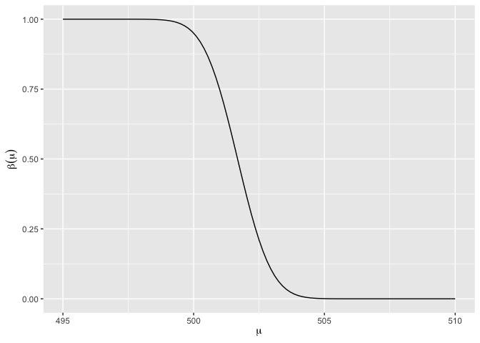

```r
erroII.media = function(n,alfa,mu,mu0,sigma2){
  k = qnorm(1-alfa,mu0,sqrt(sigma2/n))
  prob = pnorm(k, mu, sqrt(sigma2/n))
  return(prob)
}

ggplot(data = data.frame(x = c(495,510)), aes(x = x)) + stat_function(fun = erroII.media, args = list(n = 24, alfa = 0.05, mu0 = 500, sigma2 = 25)) + xlab(expression(mu)) + ylab(expression(beta(mu)))
```

### Efeito do tamanho da amostra?

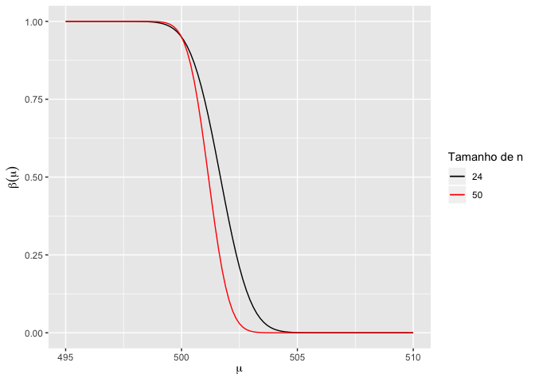

```r
ggplot(data = data.frame(x = c(495,510)), aes(x = x)) + stat_function(fun = erroII.media, args = list(n = 24, alfa = 0.05, mu0 = 500, sigma2 = 25), aes(colour = "24")) + stat_function(fun = erroII.media, args = list(n = 50, alfa = 0.05, mu0 = 500, sigma2 = 25), aes(colour = "50")) + scale_colour_manual("Tamanho de n",values = c("black","red")) + xlab(expression(mu)) + ylab(expression(beta(mu)))
```

```r
#Interpretação?
```

### 4.2 - Poder (Teste unilateral a direita)

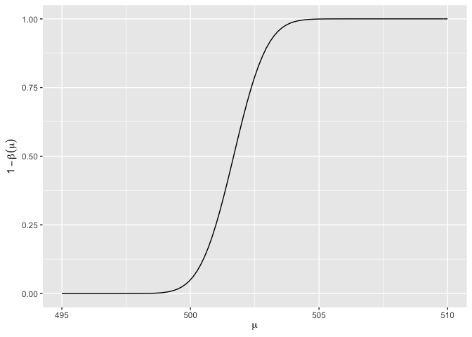

```r
poder.media = function(n,alfa,mu,mu0,sigma2){
  k = qnorm(1-alfa,mu0,sqrt(sigma2/n))
  prob = 1 - pnorm(k, mu, sqrt(sigma2/n))
  return(prob)
}

ggplot(data = data.frame(x = c(495,510)), aes(x = x)) + stat_function(fun = poder.media, args = list(n = 24, alfa = 0.05, mu0 = 500, sigma2 = 25)) + xlab(expression(mu)) + ylab(expression(1 - beta(mu)))
```

### 4.3 - P-valor (Teste unilateral a direita)

P(Observarmos valores mais extremos do que o fornecido pela amostra | $H_0$ é verdadeira).

P($\bar{X} > \bar{x}$ |$H_0$ é verdadeira) = P($\bar{X} > \bar{x}$ |$\bar{X} \sim N \left(500,\frac{25}{24} \right)$)

```r
pvalor.media = function(dados,mu0,sigma2){
  n = length(dados)
  x.barra = mean(dados)
  prob = 1 - pnorm(x.barra, mu0, sqrt(sigma2/n))
  return(prob)
}


pvalor.media(amostra,500,25)
```

```
## [1] 1.333977e-06
```